# Storm data

Kai Wakerman Powell

13 March 2016

## Synopsis

This work looks at the incidence and effects of various recorded storm events from the U.S. National Oceanic and Atmospheric Administration’s (NOAA) storm database. It examines the impact on human health and the economic impact of storms.

Results suggest that tornados produce the most impact on human health and on the economy. The impact on human health shows that tornados impact strongly on the number of fatalities and on the injuries by quite a margin. The impact on the economy is shown by the property damage, in which tornados cause as much as the next type type of events put together.

### Setting up the workspace and loading in the data

This presents the setup of the workspace and packages used. It also reads the data in from the compressed file.

```r
setwd("~/Desktop/Data Science/Reproducible Research/Assignment 2/Course-Project-2")
stormdata = read.csv(bzfile("repdata-data-StormData.csv.bz2"), header = TRUE)
```

### Data Processing

Because my computer isn’t great, it makes is easier to reduce the dataframe down. For this I’m reducing columns to only those that are needed in the following analysis.

```r
redstormdata <- stormdata[,c("EVTYPE", "FATALITIES", "INJURIES", "PROPDMG")]
```

### Health impacts of disaster events

There are two important aspects in this dataset which inform the human health impact of disaster events. The first is fatalities, the second is injuries. They are treated seperately here as there is no clear way - with the dataset given - to evaluate the value of a life against the value of an injury.

The two are compared using the same method.

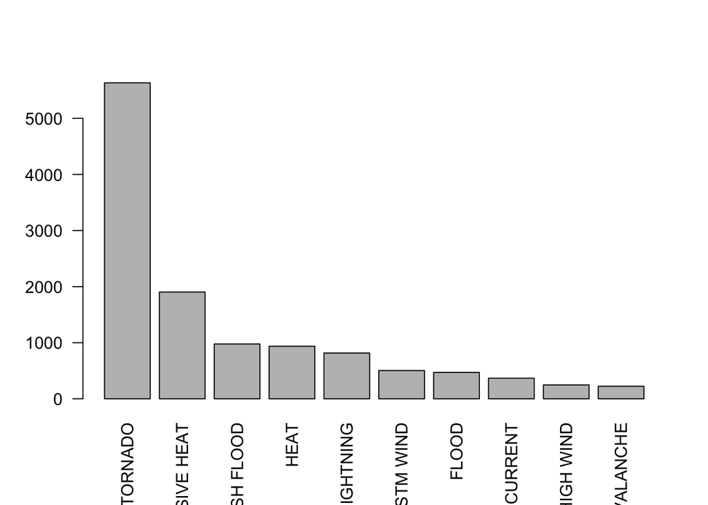

```r
fataldata <-aggregate(redstormdata$FATALITIES,by=list(redstormdata$EVTYPE), FUN=sum, na.rm=TRUE)
colnames(fataldata) = c("event.type", "fatality.total")
fatals <- fataldata[order(-fataldata$fatality.total),]
fatalities <- fatals[1:10,]
fatalities$event.type <- factor(fatalities$event.type, levels=fatalities$event.type, ordered=TRUE)
barplot(fatalities$fatality.total,names.arg = fatalities$event.type,las=2)
```

The injuries data has been treated in a similar way. However here it clearly shows that tornados produce a far greater number of injuries than its next nearest type of event.

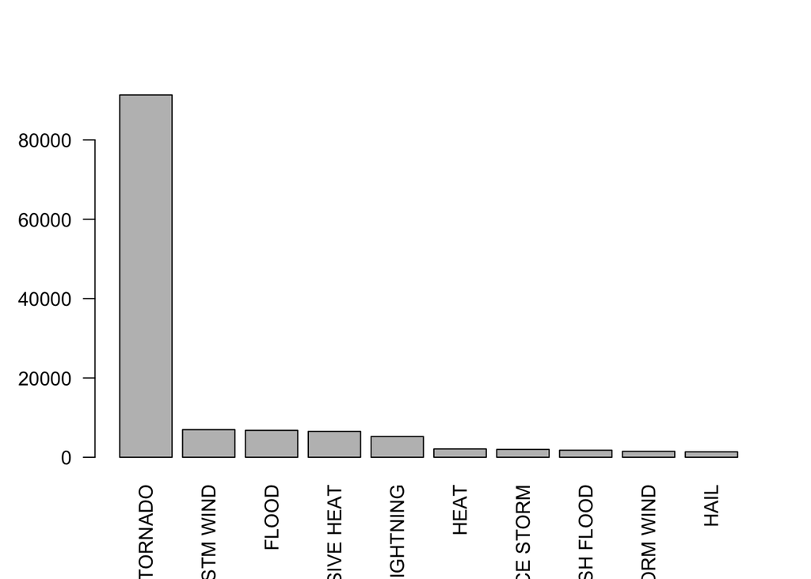

```r
injdata <-aggregate(redstormdata$INJURIES,by=list(redstormdata$EVTYPE), FUN=sum, na.rm=TRUE)
colnames(injdata) = c("event.type", "injuries.total")
inj <- injdata[order(-injdata$injuries.total),]
injuries <- inj[1:10,]
injuries$event.type <- factor(injuries$event.type, levels=injuries$event.type, ordered=TRUE)
barplot(injuries$injuries.total,names.arg = injuries$event.type,las=2)
```

The next section examines the impact of storm events on the economy. In this data set this impact is measured in the property damage variable. This is treated similarly to the previous two variables.

It shows clearly that tornados, like injuries and fatalities, produces the most property damage.

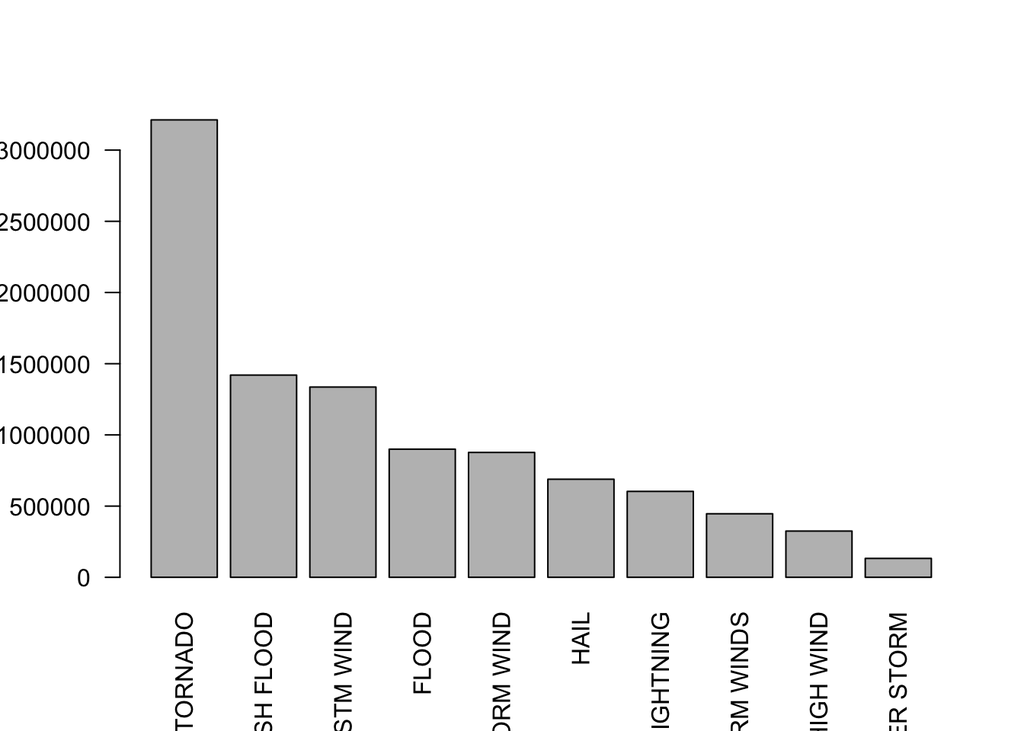

```r
dmgdata <-aggregate(redstormdata$PROPDMG,by=list(redstormdata$EVTYPE), FUN=sum, na.rm=TRUE)
colnames(dmgdata) = c("event.type", "damage.total")
dmg <- dmgdata[order(-dmgdata$damage.total),]
damage <- dmg[1:10,]
damage$event.type <- factor(damage$event.type, levels=damage$event.type, ordered=TRUE)
barplot(damage$damage.total,names.arg = damage$event.type,las=2)
```

### Results

For both human health impact and economic effects, tornados produce the most damage. In the case of injuries and property damage, this is by a siginificant amount.

```r
print(fatalities)
```

```
##         event.type fatality.total
## 834        TORNADO           5633
## 130 EXCESSIVE HEAT           1903
## 153    FLASH FLOOD            978
## 275           HEAT            937
## 464      LIGHTNING            816
## 856      TSTM WIND            504
## 170          FLOOD            470
## 585    RIP CURRENT            368
## 359      HIGH WIND            248
## 19       AVALANCHE            224
```

```r
print(injuries)
```

```
##            event.type injuries.total
## 834           TORNADO          91346
## 856         TSTM WIND           6957
## 170             FLOOD           6789
## 130    EXCESSIVE HEAT           6525
## 464         LIGHTNING           5230
## 275              HEAT           2100
## 427         ICE STORM           1975
## 153       FLASH FLOOD           1777
## 760 THUNDERSTORM WIND           1488
## 244              HAIL           1361
```

```r
print(damage)
```

```
##             event.type damage.total
## 834            TORNADO    3212258.2
## 153        FLASH FLOOD    1420124.6
## 856          TSTM WIND    1335965.6
## 170              FLOOD     899938.5
## 760  THUNDERSTORM WIND     876844.2
## 244               HAIL     688693.4
## 464          LIGHTNING     603351.8
## 786 THUNDERSTORM WINDS     446293.2
## 359          HIGH WIND     324731.6
## 972       WINTER STORM     132720.6
```